# Diagnosis and Exploration of Massively Univariate Neuroimaging Models

Wen-Lin Luo and Thomas E. Nichols

Presented by John Koo

# The General Linear Model for fMRI Data

$$Y = X \beta + \epsilon$$

- Performed for each voxel independently
- Typical setup[^1]
  - ~100,000 voxels $\implies$ ~100,000 separate models
    - Here the authors do not consider spatial dependence
  - Within each model, each observation (row) is a point in time
  - $Y$ is the *observed* fMRI signal (e.g., based on canonical function)
  - One of the columns of $X$ is the *expected* fMRI signal (e.g., something based on the canonical function)
    - Sometimes there are multiple expected signals based on different types of tasks/functions
  - Noise/error $\epsilon \sim \mathcal{N}(0, \sigma^2 V)$, where $V$ can take on some autoregressive structure
    - Here the authors assume $V = I$, i.e., no autoregression(?)
- Presence of effects at each voxel based on $t$-scores of the estimated $\hat{\beta}$’s

# The Problem

- Fitting, analyzing, and performing diagnostics for one model can be a big task
  - Linear models make many implicit and explicit assumptions
  - Breaking these assumptions can result in incorrect conclusions
- False positives or artifacts can arise from systematic noise (e.g., movement, drift, machine failure)
- Outlier detection
- But we have ~100,000 models—not feasible to do this for each model separately
- Also need to control for false discovery rate

# Proposed Model Diagnostics Methodology

1. Explore scan summaries
2. Explore model summaries
3. Explore model detail
4. Explore scan detail
5. Remediation
6. Resolution

# Scan summaries

Stacked timeseries plots of:

- Predictors (e.g., expected BOLD signal)
- Observed global BOLD signal
- Outlier counts
- Head movement

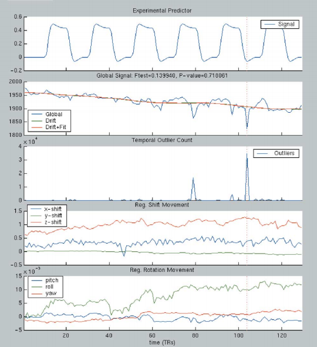

# Model Summaries

Goals:

- Model diagnostics and assumption checks
- Exploratory data analysis

Method:

1. Fit the model at each voxel
2. Check exploratory summaries to see where the signal is
   - Contrast estimates
   - Percent change threshold
3. Check diagnositics summaries to check for model validity
   - Check that residuals are iid normal

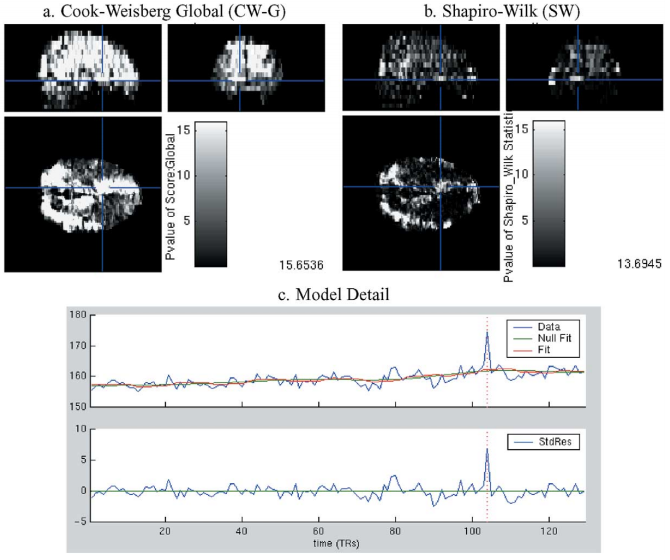

# Model and Scan Detail

Model detail

- Check model validity at the voxel level
- Instead of model summary statistics across voxels, make individual plots for
  - fitted vs. residuals
  - quantile-quantile plots
  - Fitted vs. observed

Scan detail

- Consider spatial extent/correlation of model issues
- Correspond model issues to systematic problems (such as scanning artifacts)

# Remediation and Resolution

- Data removal
  - One observation at a voxel
  - Entire voxels
- Model modification
  - Refit model adding/removing covariates
- Assess results
  - Are positives real or artifacts
  - False discovery rate

# Simulation Example

Setup

- $\text{signa}_t \sim \text{expected response}_t + \text{drift}_t + \epsilon_t$
- $\epsilon_t$ are iid normal, AR(1) with fixed $\rho \in (.1, .5)$, or AR(12)
- Models fit at each voxel (assuming iid normal residuals), then residuals computed at each voxel
- Voxel-level model rejection based on diagnostic statistics on residuals:
  - Durbin-Watson test (autoregression)
  - Cumulative periodogram test (periodicity)
  - Shapiro-Wilk test (normality)
  - Cook-Weisberg score test (heteroskedasticity)
  - Outlier test
- As expected, increased autocorrelation resulted in failing the Durbin-Watson and cumulative periodogram tests
  - CP test more useful for detecting higher-order autoregression
  - DW test failed to detect the model was incorrect for AR(12) data

# Real Data Example

- Block design word generation task
- Six cycles of rest/active with final rest cycle
- Active: Subject asked to generate a word starting with each letter of the alphabet
- 20 scans per cycle
- $128 \times 128 \times 20$ voxels of size $1.88 \times 1.88 \times 7$ mm

# Real Data Example

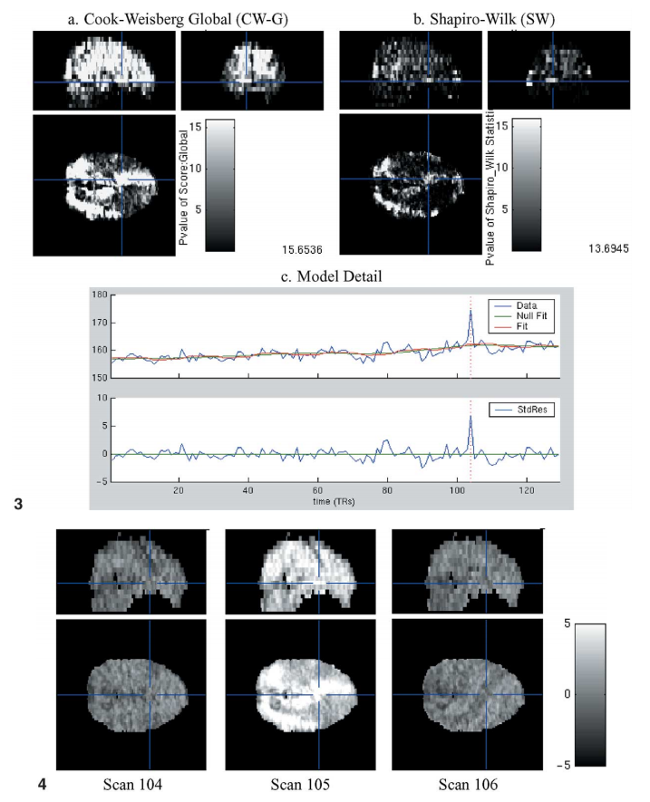

# Real Data Example

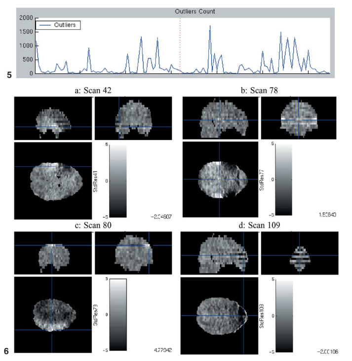

# Real Data Example

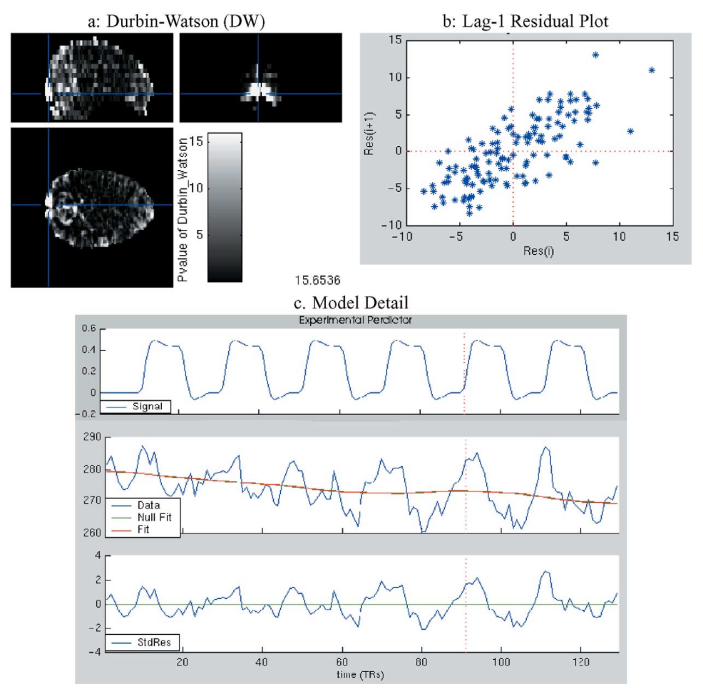

# Real Data Example

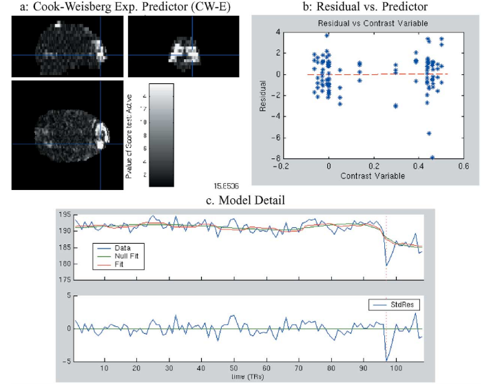

# Real Data Example

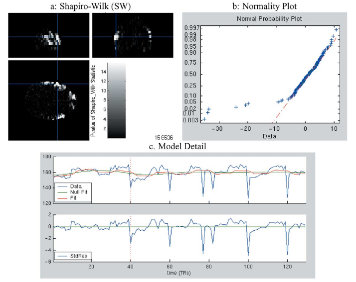

[^1]: Oxford Neuroimaging Primer https://www.fmrib.ox.ac.uk/primers/appendices/glm.pdf